# FigureYa84roast

Ying Ge, Taojun Ye

2025-5-20

## 需求描述

我要用自己的gene set做富集分析，像paper里那样用ROAST-barcode plot的方法来实现。

**扩展阅读：**“小丫画图群”对富集分析的讨论记录：https://mp.weixin.qq.com/s/O1xd5l5h33fXUWOvX3UBGw

##Requirement description

I want to use my own gene set for enrichment analysis, using the ROAST barcode plot method as described in the paper.

**Extended reading: * * Discussion record on enrichment analysis in the “Xiaoya Drawing Group”: https://mp.weixin.qq.com/s/O1xd5l5h33fXUWOvX3UBGw

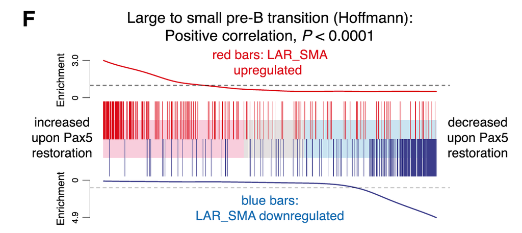

出自http://genesdev.cshlp.org/content/28/12/1337.long

fromhttp://genesdev.cshlp.org/content/28/12/1337.long

**Pathway analysis**

Gene expression signatures were tested used ROAST rotation gene set testing (Smyth 2004; Wu et al. 2010). ROAST is a hypothesis driven test that takes into account the directionality (up or down) and strength (log2 fold change) of the genes in the gene set. Gene set barcode plots were generated using the barcodeplot function of the limma package as described previously (Lim et al. 2009).

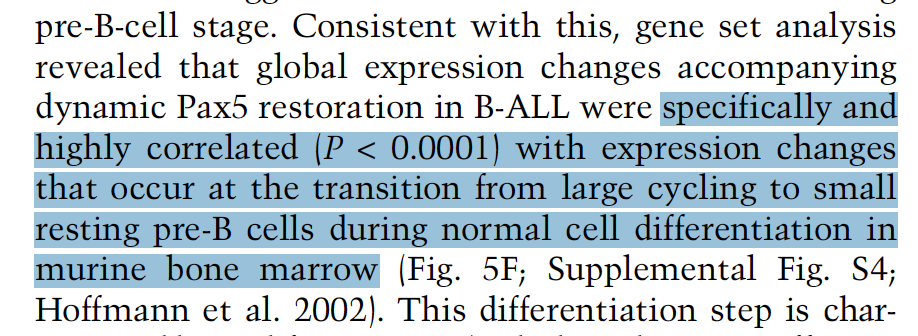

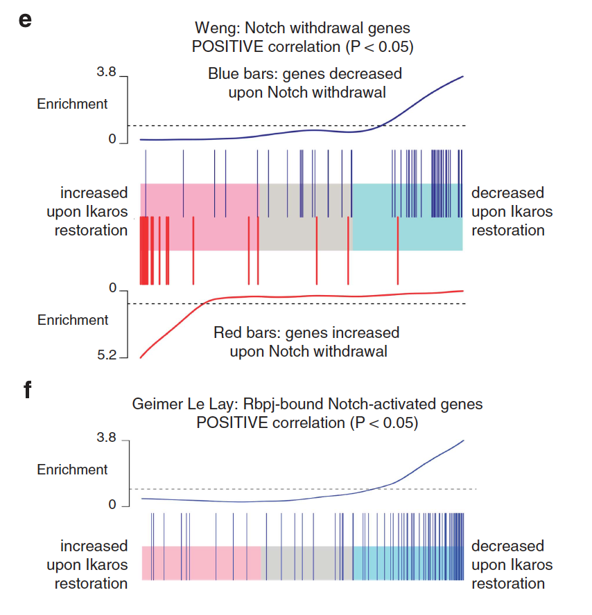

出自https://www.nature.com/articles/leu201527

Figure 2. Inducible Ikaros restoration in T-ALL in vivo. (e) Gene set analysis barcode plot, with RNA-seq differential gene expression from combined analysis of Ikaros restoration in ALL65, ALL101 and ALL211 in vivo shown as a shaded rectangle with genes horizontally ranked by moderated t-statistic. Genes upregulated upon Ikaros restoration are shaded pink (z41) and downregulated genes are shaded blue (zo1). Overlaid are a previously described set of genes induced (red bars) or repressed (blue bars) upon Notch inhibition in a murine T-ALL cell line.7 Red and blue traces above and below the barcode represent relative enrichment. P-value was computed by the roast method54 using both up- and downregulated genes. (f) Gene set analysis barcode plot as for (e) but with blue bars indicating 81 Rbpj-bound, Notch-activated genes recently identified in a murine T-cell leukemia cell line.

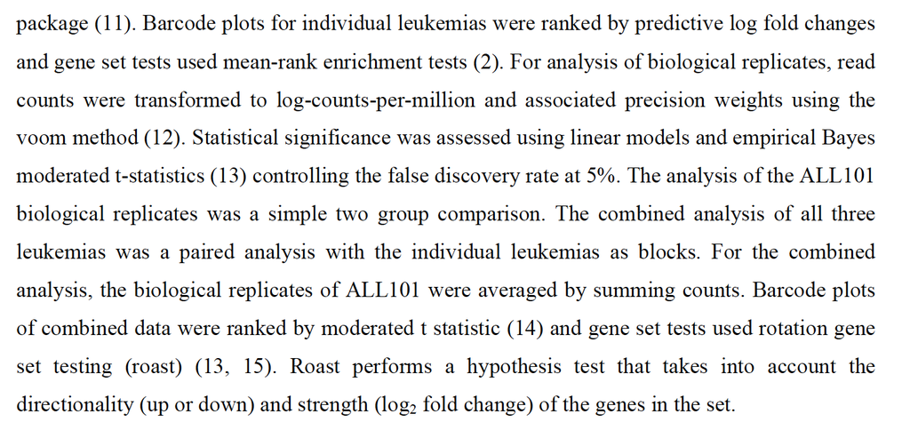

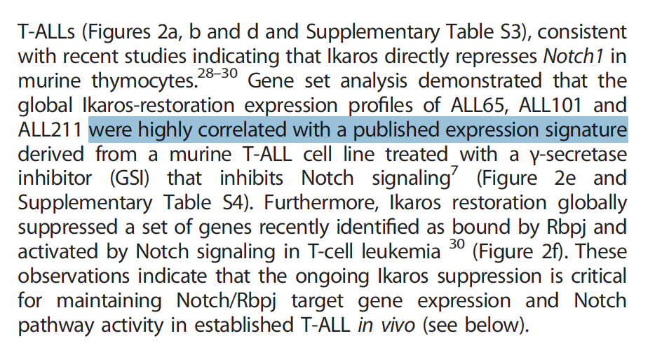

## 应用场景

roast和barcode分别用来做什么？

简单讲就是：用roast来判断上/下调基因是否显著富集目标基因集，用barcode plot来展示上/下调基因在目标基因集中的分布。roast检验一个gene set，mroast做multiple roast tests。原文：

##Application scenarios

What are roar and barcode used for respectively?

Simply put, it is to use roar to determine whether upregulated/downregulated genes significantly enrich the target gene set, and use barcode plot to display the distribution of upregulated/downregulated genes in the target gene set. Roast test a gene set, mroast does multiple roar tests. Original text:

- ROAST: The result here tells us that the immune response genes are significantly down-regulated, and additionally, mixed up and down. 出自：https://genomicsclass.github.io/book/pages/gene_set_analysis_in_R.html
- barcode plot: a barcode enrichment plot highlighting **a particular gene signature in a DE analysis ranked by moderated t-statistics**. 出自： https://academic.oup.com/nar/article/43/7/e47/2414268

适用性：适用于microarray、RNA-seq的表达矩阵，用limma给全部基因做差异表达分析，不需要筛差异表达基因。

Applicability: Suitable for microarray and RNA seq expression matrices, perform differential expression analysis on all genes using limma without screening for differentially expressed genes.

## 环境设置

使用国内镜像安装包

##Environment settings

Use domestic image installation package

```r
options("repos"= c(CRAN="https://mirrors.tuna.tsinghua.edu.cn/CRAN/"))
options(BioC_mirror="http://mirrors.ustc.edu.cn/bioc/")
install.packages("statmod")
```

加载包

library packages

```r
# 加载limma包，用于基因表达数据分析和差异表达分析
# Load the limma package for gene expression data analysis and differential expression analysis
library(limma)
# 设置系统环境变量，使R显示英文报错信息
# Set the system environment variable to display error messages in English
Sys.setenv(LANGUAGE = "en")

# 设置选项，禁止将字符串自动转换为因子类型
# Set the option to prevent automatic conversion of strings to factors
options(stringsAsFactors = FALSE)
```

## 输入文件

需要三种输入文件：

用后两个文件做差异表达分析

##Input file

Three types of input files are required:

-EasyInput_Set1.csv and EasyInput_Set2.csv, one or two. The gene set/signature that interests oneself, such as a certain pathway, a certain GO term, a response gene found under a certain condition in someone else’s article, a protein that interacts with the target protein, and so on. In short, as long as you can articulate the meaning of the gene set/signature.

Perform differential expression analysis using the last two files

```r
# 读取表达矩阵数据，第一列作为行名（通常为基因ID）
# Read expression matrix data, using the first column as row names (usually gene IDs)
expr <- read.csv("easy_input_expr.csv", row.names = 1)
head(expr)  # 查看数据前几行
```

```
##        GSM431121 GSM431122 GSM431123 GSM431124 GSM431125 GSM431126
## RPL41   40030.68  40292.92  40345.05  40397.75  40719.06  40345.05
## ANXA2   31230.28  35752.89  37174.10  36584.56  37906.75  36292.69
## TPT1    34509.26  33224.73  34509.26  34528.11  35306.72  34509.26
## PLK1    33776.06  33099.00  34648.96  34953.17  34874.99  35081.78
## RPL23A  34933.65  34657.47  33335.98  33957.87  33656.04  33879.19
## RPS2    34138.56  32664.69  32056.11  32664.69  32664.69  32664.69
```

```r
# 读取样本信息表，使用制表符分隔，第一行为表头
# Read sample information table with tab-separated values and header row
Targets <- read.table("easy_input_pheno.txt", sep = "\t", header = T)
Targets  # 显示样本信息内容
```

```
##                      title condition
## 1  HMLER, paclitaxel, rep1         a
## 2  HMLER, paclitaxel, rep2         a
## 3  HMLER, paclitaxel, rep3         a
## 4 HMLER, salinomycin, rep1         b
## 5 HMLER, salinomycin, rep2         b
## 6 HMLER, salinomycin, rep3         b
```

```r
# 构建设计矩阵，用于线性模型分析，~0表示不包含截距项
# Construct design matrix for linear model analysis, ~0 indicates no intercept term
design <- model.matrix(~ 0 + condition, data = Targets)
design  # 显示设计矩阵结构
```

```
##   conditiona conditionb
## 1          1          0
## 2          1          0
## 3          1          0
## 4          0          1
## 5          0          1
## 6          0          1
## attr(,"assign")
## [1] 1 1
## attr(,"contrasts")
## attr(,"contrasts")$condition
## [1] "contr.treatment"
```

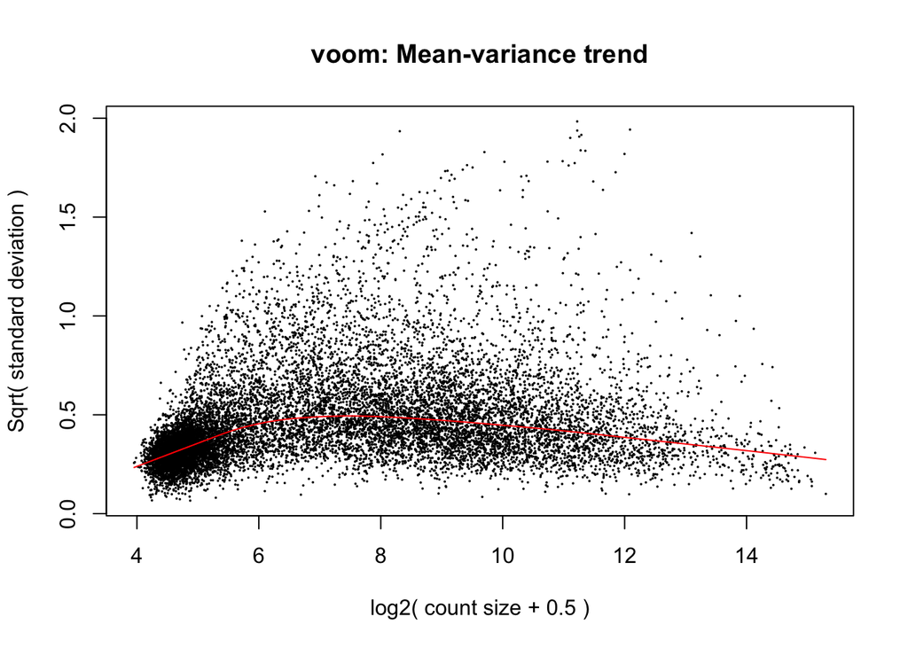

```r
# 使用voom方法对RNA-seq数据进行预处理，使其适合线性模型分析
# Preprocess RNA-seq data using voom to make it suitable for linear modeling
expr <- voom(expr, design, plot = TRUE)
```

```r
# 读取两个基因集数据，通常包含感兴趣的基因列表
# Read two gene sets, typically containing lists of genes of interest
geneSet1 <- read.csv("easy_input_set1.csv")
head(geneSet1)  # 查看基因集1的前几行
```

```
##      Gene
## 1    CD40
## 2    DBF4
## 3 DCLRE1B
## 4    DNTT
## 5   POLA1
## 6   POLD1
```

```r
geneSet2 <- read.csv("easy_input_set2.csv")

# 创建逻辑索引，标记表达矩阵中属于各基因集的基因行
# Create logical indices to mark rows in the expression matrix belonging to each gene set
Set1index <- rownames(expr) %in% geneSet1$Gene
Set2index <- rownames(expr) %in% geneSet2$Gene

# 使用roast方法对单个基因集进行功能富集分析
# Perform gene set enrichment analysis for a single gene set using roast method
roast(expr, Set1index, design)
```

```
##          Active.Prop      P.Value
## Down               0 1.0000000000
## Up                 1 0.0002500625
## UpOrDown           1 0.0005000000
## Mixed              1 0.0005000000
```

```r
# 使用mroast方法同时对多个基因集进行富集分析，参数2表示置换次数
# Perform multiple gene set enrichment tests simultaneously using mroast, parameter 2 is permutation times
mroast(expr, list(Set1index,Set2index), design, 2)
```

```
##      NGenes PropDown PropUp Direction PValue   FDR PValue.Mixed FDR.Mixed
## set1     32        0      1        Up  5e-04 5e-04        5e-04     5e-04
## set2     30        0      1        Up  5e-04 5e-04        5e-04     5e-04
```

**题外话：**如果你感兴趣的比较多，还可以写成循环，挑出pvalue较小的gene set用来画图。

**Off topic: * * If you are interested in more, you can also write it as a loop and select the gene set with smaller p-value for drawing.